# index

Traqueostomias

em desmame ventilatório

Gonçalo Torrinha, MD

Serviço de Medicina Intensiva, Hospital de Braga | Escola de Medicina, Universidade do Minho

## Morbi-mortalidade do desmame ventilatório<sup>1</sup><sup>,</sup><sup>2</sup><sup>,</sup><sup>3</sup><sup>,</sup><sup>4</sup><sup>,</sup><sup>5</sup>

- Prevalência:
  - Falência primária de **ventilação**: 20 a 31% da generalidade dos doentes críticos
  - Falência primária de **via aérea/estímulo ventilatório**: 14 a 18% na generalidade dos doentes, mas 15% a 47% dos doentes neurocríticos
- Mortalidade:
  - Falência de **desmame**: entre 24 a 39%, a 12 meses 40 a 75%
  - Falência de **extubação** associada a >2x mortalidade
- LOS (mediana): 22 a 25 dias em SMI, 45 a 51 dias no Hospital.
[^1]: Shah et al. Breathe 2024. DOI: 10.1183/20734735.0122-2024
[^2]: Ghiani et sal. BMC Pulmonary Medicine 2026. DOI: 10.1186/s12890-026-04252-9
[^3]: Alghamdi et al. The Egyptian Journal of Bronchology 2026. DOI:10.1186/s43168-026-00521-7
[^4]: Medrinal et al. Annals of Intensive Care 2026. DOI: 10.1016/j.aicoj.2026.100045
[^5]: Dziewas et al. Neurological Research and Practice 2025. DOI: 10.1186/s42466-025-00376-1

## O problema de decisão

Traqueostomia:

**1. O doente *necessita*?**

**2. Quando?**

**3. Como?**

## Indicações<sup>1</sup><sup>,</sup><sup>2</sup>

1. Ventilação mecânica (previsivelmente) prolongada (maioria)
2. Falência de Extubação (precoce + tardia)
3. Proteção de Via Aérea
   1. Disfunção Neurológica (UCIP ~15% → UCIN ~45%)
   2. Distorção Anatómica + outras
[^6]: Alghamdi et al. The Egyptian Journal of Bronchology 2026. DOI:10.1186/s43168-026-00521-7
[^7]: Dziewas et al. Neurological Research and Practice 2025. DOI: 10.1186/s42466-025-00376-1

## Para quê?

- Redução de espaço morto e trabalho respiratório (WOB)
  - Menos *espaço-morto*: redução em 30 a 50%<sup>1</sup>
  - Menos resistência de via aérea:
    - Maior calibre e menor comprimento
    - Menor compromisso por compressão externa<sup>2</sup>
[^8]: Amada et al. British Journal of Hospital Medicine 2026. DOI: 10.31083/BJHM50155
[^9]: Ghattas et al. Journal of Thoracic Disease 2021. DOI: 10.21037/jtd-19-4121

## Para quê?

- Redução de espaço morto e trabalho respiratório (WOB)

$$\Delta P \propto \frac{L}{r^4}$$

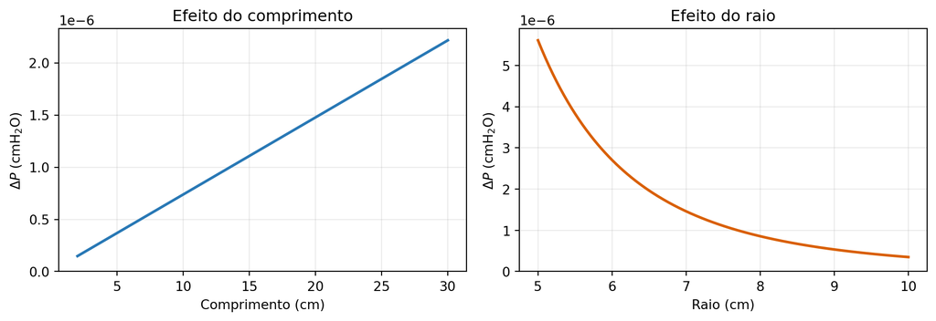

## Para quê?

- Redução de espaço morto e trabalho respiratório (WOB)
- Otimização na gestão de S/A e Delirium
  - Menor **reatividade ao tubo** → desmame de sedo-analgesia mais precoce<sup>1</sup>
- Margem para reabilitação
  - Retorno prococe de **fonação**<sup>2</sup> e **mobilização** precoce<sup>3</sup>
  - Retorno precoce de **deglutição**<sup>4</sup> → Efeito indireto por prevenção de delirium
- Correta **toilette brônquica** → aspirações subglóticas mais eficazes<sup>3</sup>
- Prevenção de trauma de CV e aritnóides<sup>1</sup>
[^10]: Alghamdi et al. The Egyptian Journal of Bronchology 2026. DOI:10.1186/s43168-026-00521-7
[^11]: Amada et al. British Journal of Hospital Medicine 2026. DOI: 10.31083/BJHM50155
[^12]: Medrinal et al. Annals of Intensive Care 2026. DOI: 10.1016/j.aicoj.2026.100045
[^13]: Ghattas et al. Journal of Thoracic Disease 2021. DOI: 10.21037/jtd-19-4121

## Para quê? E quando?

**TracMan Trial**<sup>1</sup>

- 2004 a 2011, 889 analisados
- Traqueostomias ≤4 dias *versus* >10 dias
- Resultados:
  - Mortalidade a 30 dias: ~31% em ambos, p>0.5
    - Sem diferenças à alta de SMI, hospitalar, 12 e 24 meses
  - LOS: semelhante.
  - Dias livres de antibiótico: semelhante.
  - **Duração de sedação (mediana): 5 *versus* 8 dias**, p<0.001
[^14]: Young et al. The TracMan Randomized Trial. JAMA 2013. DOI:10.1001/jama.2013.5154

## Para quê? E quando?

**TracMan Trial**<sup>1</sup>: o único RCT, resultados debatíveis

- Exclusão explícita de doentes neurocríticos
  - *because our study centers indicated these patients usually receive early tracheostomies*
- 53.7% (244/454) do grupo tardio **nunca** foi traqueostomizado
  - 167 recuperaram espontaneamente → extubados → alta
- Análise de dias de antibiótico, sem análise de pneumonias associada a intubação (PAI)
[^15]: Young et al. The TracMan Randomized Trial. JAMA 2013. DOI:10.1001/jama.2013.5154

## Para quê? E quando?

**Nova Evidência**

1. Traqueostomias precoces previnem PAI?
   - Boni et al. (2025): *Umbrella review* + nova meta-análise + análise sequencial (19 RCT, 3421 pacientes)<sup>1</sup>
   - **Precoce previne PAI** mas sem benefício claro na mortalidade.
   - Não há consenso na definição de precoce ou tardia → 7 dias (RCT) *vs* 10 dias (RS)
   - Fraca qualidade de evidência principalmente por critérios de diagnóstico muito variáveis
[^16]: Boni et al. BMJ Open Respir Res 2025. DOI: 10.1136/bmjresp-2024-002434

## Para quê? E quando?

**Nova Evidência**

1. Não usar só por potencial protetor de PAI ou para reduzir tempo de VMI; **<4 dias sem redução de mortalidade evidente.** (Guidelines Francesas<sup>1</sup><sup>,</sup><sup>2</sup>)
2. Traqueostomias facilitam desmame ventilatório?
   - Ghiani et al. (2026): coorte retrospetiva, 12 anos → 440 doentes sob VMI<sup>3</sup>
   - Precoce definida como <14 dias, *confirmado com <10 dias*
   - Sem diferenças em % de VMI prolongada, falência de descanulação ou mortalidade
     - Até em mecânica ventilatória e reserva funcional
[^17]: Troillet et al. Annals of Intensive Care 2018. DOI:10.1186/s13613-018-0381-y
[^18]: Medrinal et al. Annals of Intensive Care 2026. DOI: 10.1016/j.aicoj.2026.100045
[^19]: Ghiani et sal. BMC Pulmonary Medicine 2026. DOI: 10.1186/s12890-026-04252-9

## Para quê? E quando?

**Nova Evidência**

1. Não usar só por potencial protetor de PAI ou para reduzir tempo de VMI; **<4 dias sem redução de mortalidade evidente.**
2. Ser mais precoce não facilita o desmame ventilatório. (Guidelines Francesas<sup>1</sup><sup>,</sup><sup>2</sup>)
3. Quando então?
- **Nunca antes dos 4 dias**
- **Pensar em todos os doentes com falência de desmame >7 dias**
- *Mais precoce* se **patologia neuromuscular adquirida reversível** (e.g. Guillain-Barré)
[^20]: Troillet et al. Annals of Intensive Care 2018. DOI:10.1186/s13613-018-0381-y
[^21]: Medrinal et al. Annals of Intensive Care 2026. DOI: 10.1016/j.aicoj.2026.100045
[^22]: Young et al. The TracMan Randomized Trial. JAMA 2013. DOI:10.1001/jama.2013.5154
[^23]: Boni et al. BMJ Open Respir Res 2025. DOI: 10.1136/bmjresp-2024-002434

## Como?

- Opção 1: Percutânea
- Opção 2: Cirúrgica
- Opção 3: Híbrida

## Como?

- Opção 1: Percutânea<sup>1</sup><sup>,</sup><sup>2</sup><sup>,</sup><sup>3</sup><sup>,</sup><sup>4</sup>
  - Minimamente invasiva, técnica de Seldinger ± Broncoscópio; ± Ecógrafo
  - Vantagens:
    - Menos risco associado a transporte
    - Taxas de infeção mais baixas (menor invasividade)
    - Vantagem *ligeira* em LOS em UCI e hospitalar
  - Limitações/Contraindicações:
    - Dificuldade na palpação de anéis traqueais; Obesidade
    - Imobilização cervical
    - Massas cervicais; Coagulopatia (sem controlo)
[^24]: Troillet et al. Annals of Intensive Care 2018. DOI:10.1186/s13613-018-0381-y
[^25]: Locatello et al. The Laryngoscope 2026. DOI: 10.1002/lary.70702
[^26]: Alghamdi et al. The Egyptian Journal of Bronchology 2026. DOI:10.1186/s43168-026-00521-7
[^27]: Ghattas et al. Journal of Thoracic Disease 2021. DOI: 10.21037/jtd-19-4121

## Como?

- Opção 1: Percutânea
- Opção 2: Cirúrgica <sup>1</sup><sup>,</sup><sup>2</sup><sup>,</sup><sup>3</sup>
  - Disseção cirúrgica em bloco operatório, tipicamente por ORL
  - Vantagens:
    - Alterações Anatómicas
    - Dificuldade técnica de realização de traqueostomia percutânea
    - Elevado risco de procedimento
  - Limitações/Contraindicações:
    - Transporte de elevado risco
    - Custos elevados de procedimento
    - Atrasos de agendamento
[^28]: Locatello et al. The Laryngoscope 2026. DOI: 10.1002/lary.70702
[^29]: Alghamdi et al. The Egyptian Journal of Bronchology 2026. DOI:10.1186/s43168-026-00521-7
[^30]: Winchester et al. Head & Neck 2025. DOI: 10.1002/hed.27948

## Como?

- Opção 1: Percutânea
- Opção 2: Cirúrgica
- Opção 3: Híbrida<sup>1</sup><sup>,</sup><sup>2</sup>
  - Abordagem cirúrgica, **na unidade**, por cirurgião e gestão anestésica pelo SMI
  - Vantagens logísticas da técnica percutânea sem as limitações associadas
    - Redução de atrasos de agendamento (84 vs 55 horas para primeira avaliação)
    - Sem aumentar taxa de complicações cirúrgicas
    - Redução de custos relatado entre 54 a 73%
    - Vantagem *mínima* no tempo de procedimento
[^31]: Locatello et al. The Laryngoscope 2026. DOI: 10.1002/lary.70702
[^32]: Winchester et al. Head & Neck 2025. DOI: 10.1002/hed.27948

## O problema de decisão

Traqueostomia:

1. O doente *necessita*?
2. Quando?
3. Como?
4. Quando e como **parar**?

## Desmame e descanulação

- Duas grandes **referências da literatura**:
  - Orientações Francesas de 2026<sup>1</sup>
  - *Framework* de Descanulação Neurológica de 2025<sup>2</sup>
- Três grandes linhas de pensamento:
  1. **Desmame ventilatório**
  2. **Otimização da via aérea**
  3. **Descanulação**
[^33]: Medrinal et al. Annals of Intensive Care 2026. DOI: 10.1016/j.aicoj.2026.100045
[^34]: Dziewas et al. Neurological Research and Practice 2025. DOI: 10.1186/s42466-025-00376-1

## 1. Desmame Ventilatório no traqueostomizado

- Privilegiar **desmame mais agressivo (peça em T ou nariz artificial)** versus pressão de suporte)
  - 500 adultos ventilados >21 dias
    - *31% tolerou 5 dias sem assistência* → excluídos
    - Restantes estratificados: falência precoce (<12h) ou tardia.
    - Dois grupos:
      - D1-2 *12h on 12h off* → D3 a +5 *24h off*
      - PS desmame q8h 2cmH<sub>2</sub>O até 6cmH<sub>2</sub>O
    - **Desmame mais curto** (15 vs 19 dias) sem impacto na mortalidade
      - Diferenças só no grupo tardio

## 2. Otimização de Via Aérea

- Acompanhar desmame ventilatório com **cuff desinsuflado + válvula fonatória**
  - Cuff vazio → restabelece pressão subglótica e elevação laríngea → reduz micro- aspirações em cerca de 15%
  - Válvula fonatória → direciona fluxo de ar → reduz aspiração em 50%
  - 181 doentes traqueostomizados
    - Patência supraglótica confirmada com oclusão da traqueostomia
    - **Menos tempo até desmame** (3 dias vs 8 dias) e **menor taxa de infeções respiratórias** (20% vs 36%)
    - Limitações:
      - Excluídos doentes neurológicos e com disfagia severa
      - Ar humificado a 69L/min no grupo de intervenção versus 55L/min no controlo

## 2. Otimização de Via Aérea

- Acompanhar desmame ventilatório com **cuff desinsuflado + válvula fonatória**
- Troca de cânula programada **não está recomendada**
- Considerar troca de cânula no contexto de downsizing para otimizar desmame ventilatório
  - Três grandes estudos: Heliyon 2024, Manometry 2009, Wahla 2020
    - Cânula interna aumenta resistência da via aérea em 2 a 3 vezes
    - Trocas rotineiras <6 dias aumentam complicações sem benefício
    - Comparação calendário vs troca individualizada
      - *Redução de um tamanho se doente falhar obturação da cânula/válvula fonatória* (↑ trabalho respiratório ou P<sub>IT</sub> > 10cmH<sub>2</sub>O)
        - Melhor tolerância a trials (78% vs 95%)
        - **Preditor independente de sucesso de descanulação**

## 3. Descanulação

- Quando considerar?
  - Após desmame ventilatório, se sem desfagia major, **guiar pela frequência de aspirações** vs por testes de obturação 24h
    - Espaço morto supra-estoma → *30% do trabalho respiratório* → *falência de desmame*
    - 330 pacientes, multicêntrico
      - Seleção: cuff desinsuflado, teste de 5 minutos sem estridor + teste de deglutição com 50cc de água
      - Todos: alto fluxo + cânula aberta e cuff vazio; se ≤2 aspirações q8h em 24h:
        1. Descanular imediatamente
        2. Obturação 24h e vigiar dificuldade respiratória
      - Grupo A: **menos tempo de desmame** (6 vs 13 dias), **menos infeções respiratórias**, **menos recanulações** (2.4% vs 5.6%), e **menor estadia hospitalar** (48 vs 62 dias)

## 3. Descanulação

- Como orientar?
  - Abordagem multidisciplinar
  - Ainda sem benefício claro *verificação endoscópica* em todos → testes clínicos parecem suficientes
    - Reservar para:
      - Intolerância à obturação
      - Alterações inesperadas durante desmame
      - Doentes neurocríticos

## 3. Descanulação

- Como orientar?

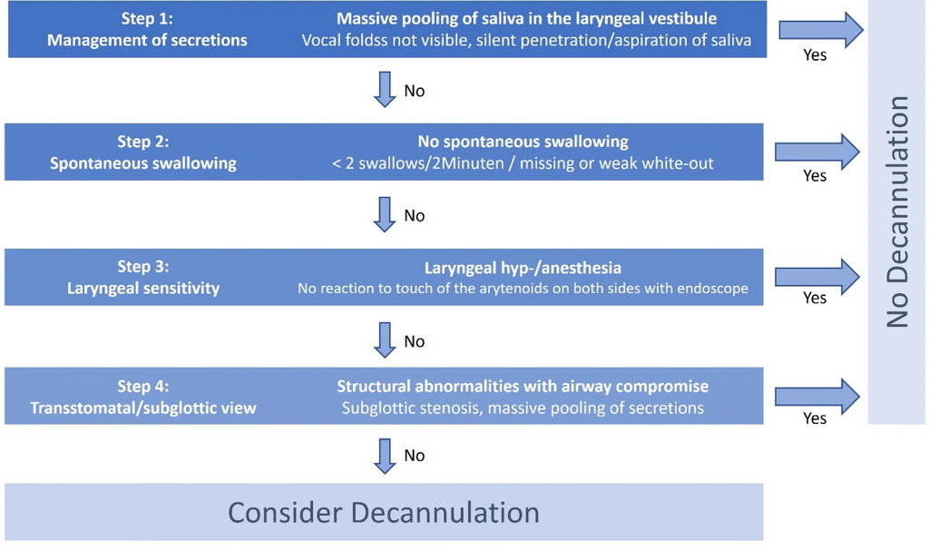

## 3. Descanulação

- Como orientar?
  - Abordagem multidisciplinar
  - Ainda sem benefício claro *verificação endoscópica* em todos → testes clínicos parecem suficientes
    - Protocolo SESETD
  - Bundles de intervenção parecem ser eficazes → algoritmo sugerido por Dziewas et al<sup>1</sup>
    - **A<sup>2</sup>BC Pathway**
[^35]: Dziewas et al. Neurological Research and Practice 2025. DOI: 10.1186/s42466-025-00376-1

## 3. Descanulação

- Como orientar?
  - **A<sup>2</sup>BC Pathway** → Diagnóstico:

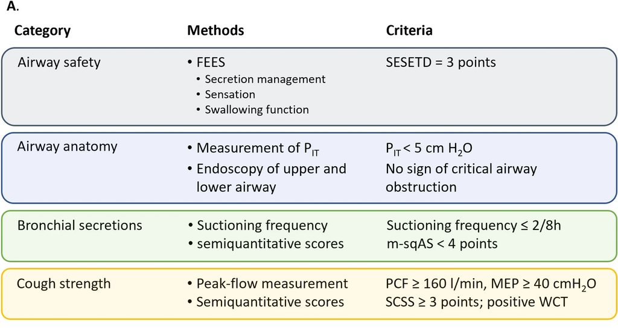

## 3. Descanulação

- Como orientar?
  - **A<sup>2</sup>BC Pathway** → Abordagem:

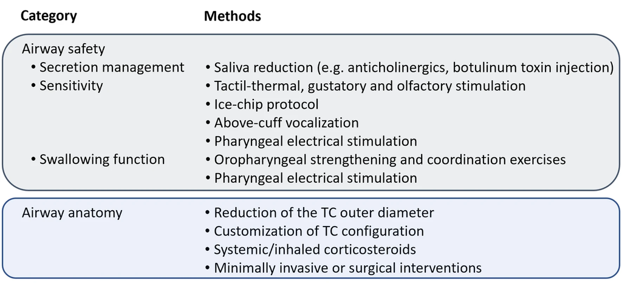

## 3. Descanulação

- Como orientar?
  - **A<sup>2</sup>BC Pathway** → Abordagem:

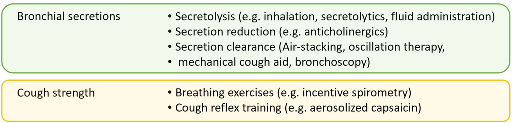

## Mensagens para levar para casa

1. **Indicação:** a traqueostomia serve o desmame de doentes com VM prolongada (>7 dias), falência de extubação e proteção de via aérea.
2. **Timing:** benefício antes dos 4 dias muito questionável; clinicamente difícil estimar VMI prolongada.
3. **Técnica:** a percutânea continua a ser a primeira linha. A híbrida surge na otimização da abordagem cirúrgica → feita na unidade reduz atrasos e custos.
4. **Desmame:** Privilegiar a peça em T ou o nariz artificial em vez da pressão de suporte.
5. **Via aérea:** ser agressivo no desmame parece paradoxal mas permite rapidez na proteção independente de via aérea.
6. **Descanulação:** guiar pela frequência de aspirações. Seguir protocolos ↑ Qualidade e Reprodutibilidade

Obrigado

Gonçalo Torrinha, MD, goncalo.torrinha@ulsb.min-saude.pt